# Reproducible Research: Peer Assessment 1

Wolfgang Ecker-Lala

## Loading and preprocessing the data

Data will be loaded from the datasource file named “activity.csv”. This file has been downloaded and imported by

```r
filename <- "C:/MATH-UP/DataScience/Coursera DataScientist/Reproducible Research/Assignment1/activity.csv"

myData <- read.csv(filename,stringsAsFactor=FALSE)
```

In order to get for field “date” datatype POSIXct we make following transformation: Data will be loaded from the datasource file named “activity.csv”. This file has been downloaded and imported by

```r
library(lubridate)
myData$date<-ymd(myData$date)
```

## What is mean total number of steps taken per day?

The total number of steps taken per day is calculated by

```r
dailyActivity<-aggregate(steps~date,data=myData,FUN=sum)
```

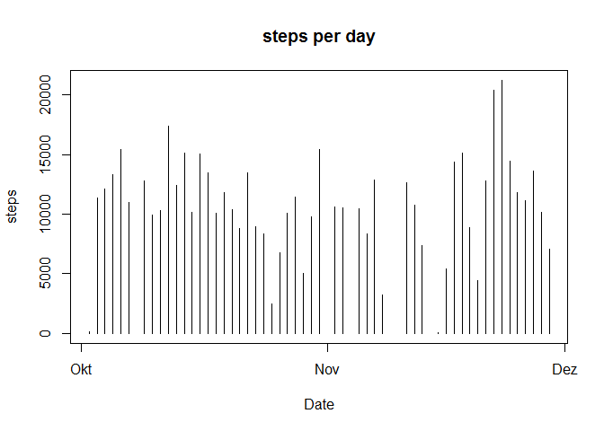

```r
plot(dailyActivity$date,dailyActivity$steps,type="h",ylab="steps",xlab="Date",main="steps per day")
```

The calculated mean of daily sums of steps can be retrieved by

```r
stepMean<-mean(dailyActivity$steps)
```

So for the value of this mean we get 10766.18868.

In same way the calculated median of sums of steps can be retrieved by

```r
stepMedian<-median(dailyActivity$steps)
```

So for the value of this median we get 10765.

## What is the average daily activity pattern?

In order to be able to answer this question we have to do following transformation and calculation before:

```r
dailyActivityInterval<-aggregate(steps~interval,data=myData,FUN=mean)
allDaysMean<-mean(myData$steps,na.rm=TRUE)
```

So the daily activity pattern is like

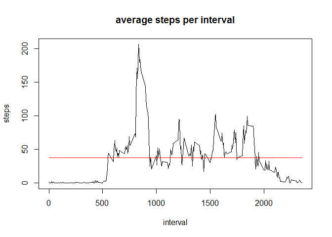

```r
plot(dailyActivityInterval$interval,dailyActivityInterval$steps,type="l",xlab="interval",ylab="steps",main="average steps per interval",ylim=range(dailyActivityInterval$steps))
par(new=TRUE)
plot(c(min(dailyActivityInterval$interval),max(dailyActivityInterval$interval)),c(allDaysMean,allDaysMean),axes=FALSE,type="l",col="RED",xlab="",ylab="",main="",ylim=range(dailyActivityInterval$steps))
```

The red line there shows the average of steps across all days.

Now we like to get the interval on average across all the days with maximum number of steps. For this we do following calculation.

```r
maxIntervalSteps<-max(dailyActivityInterval$steps)
maxIntervalBySteps<-dailyActivityInterval[dailyActivityInterval$steps==maxIntervalSteps,]
```

And the value of the interval with maximum number of steps is 835.

## Imputing missing values

The total number of missing values can be calculated by

```r
recordsNA<-length(myData[is.na(myData$steps) | is.na(myData$interval) | is.na(myData$date) ,1])
```

and the value is 2304.

Missing values can be filled using following strategy:

Use the average value of steps of the corresponding interval over all observations.

A new dataset can be created by

```r
myNewData<-myData
missingSteps<-which(is.na(myData$steps)==TRUE)
for (i in 1:length(missingSteps)) {
  myNewData[missingSteps[i],]$steps<-dailyActivityInterval[dailyActivityInterval$interval==myNewData[missingSteps[i],]$interval,]$steps
}
```

In order to be able to plot again a histogram with these modified data we have to do following calculation before.

```r
dailyNewActivity<-aggregate(steps~date,data=myNewData,FUN=sum)
```

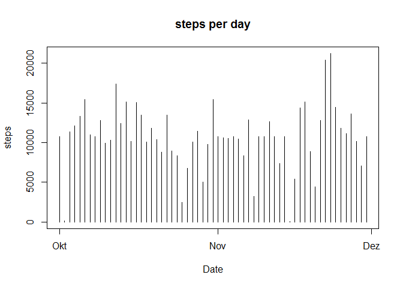

```r
plot(dailyNewActivity$date,dailyNewActivity$steps,type="h",ylab="steps",xlab="Date",main="steps per day")
```

Mean and median of this modified dataset can be calculated by

```r
stepNewMean<-mean(dailyNewActivity$steps)
stepNewMedian<-median(dailyNewActivity$steps)
```

And we get following values:

Mean: 10766.18868

Median: 10766.18868

## Are there differences in activity patterns between weekdays and weekends?

We introduce a new field named “dayOfWeek” which can have the value *weekday* (monday, tuesday, wednesday,thursday,friday) or *weekend* (saturday, sunday).

```r
myNewData$dayOfWeek$dayOfWeek<-"weekday"
myNewData[weekdays(myNewData$date)=="Sonntag" | weekdays(myNewData$date)=="Samstag",]$dayOfWeek<-"weekend"
```

In order to be able to show the differences between activities of weekday and weekend we do following precalculation.

```r
weekdayData<-myNewData[myNewData$dayOfWeek=="weekday",]
weekendData<-myNewData[myNewData$dayOfWeek=="weekend",]
dailyWeekdayInterval<-aggregate(steps~interval,data=weekdayData,FUN=mean)
dailyWeekendInterval<-aggregate(steps~interval,data=weekendData,FUN=mean)
```

The following panel plot shows now the differences.

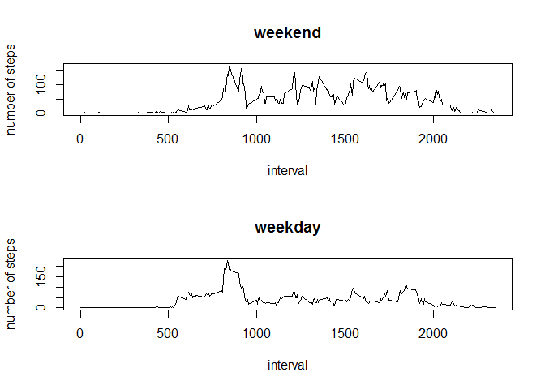

```r
par(mfrow=c(2,1))
plot(dailyWeekendInterval$interval,dailyWeekendInterval$steps,type="l",xlab="interval",ylab="number of steps",main="weekend",ylim=range(dailyWeekendInterval$steps))
plot(dailyWeekdayInterval$interval,dailyWeekdayInterval$steps,type="l",xlab="interval",ylab="number of steps",main="weekday",ylim=range(dailyWeekdayInterval$steps))
```